# Pearsonův test

2024-10-26

Pro Pearsonův test nám poslouží dataset **Steam_2024_bestRevenue_1500.csv**, který obsahuje 1500 nejvýdělečnějších videoher na platformě Steam za rok 2024.

```r
data<-read.csv("Steam_2024_bestRevenue_1500.csv")
```

```python
import pandas as pd
import seaborn as sns
import matplotlib.pyplot as plt
import pingouin as pg

data = pd.read_csv("Steam_2024_bestRevenue_1500.csv")
```

Ten obsahuje celkem 11 sloupců, přičemž nás budou zajímat dva z nich: **avgPlaytime** (průměrná stravená herní doba) a **revenue** (celkové tržby). Dávalo by smysl, že čím větší je průměrná strávená herní doba, tím větší by byly i celkové tržby, proto musíme zformulovat odpovídající hypotézy:

Nulová hypotéza (H<sub>0</sub>): Neexistuje žádný vztah mezi průměrnou strávenou herní dobou a celkovými tržbami.

Alternativní hypotéza (H<sub>1</sub>): Existuje pozitivní vztah mezi průměrnou strávenou herní dobou a celkovými tržbami.

Jelikož máme dvě kvantitativní parametrické proměnné, využijeme Pearsonův test.

```r
test <- cor.test(data$avgPlaytime, data$revenue, method = 'pearson')
test
```

```
##
##  Pearson's product-moment correlation
##
## data:  data$avgPlaytime and data$revenue
## t = 3.2011, df = 1498, p-value = 0.001398
## alternative hypothesis: true correlation is not equal to 0
## 95 percent confidence interval:
##  0.03194581 0.13248671
## sample estimates:
##        cor
## 0.08242598
```

```python
correlation_test = pg.corr(data['avgPlaytime'], data['revenue'], alternative='two-sided')
```

Vidíme, že P-hodnota je velmi nízká (0.001398), tudíž nulová hypotéza o neexistenci vztahu mezi proměnnými může být zamítnuta. Samotná hodnota korelace (0.08242598) je pozitivní, tudíž můžeme říct, že hry, které mají delší průměrnou dobu hraní, mají tendenci prodávat více kopií, ale vztah je velmi slabý.

Pro grafické vykreslení dané korelace můžeme využít knihovnu **ggstatsplot** (**seaborn** v případě Pythonu).

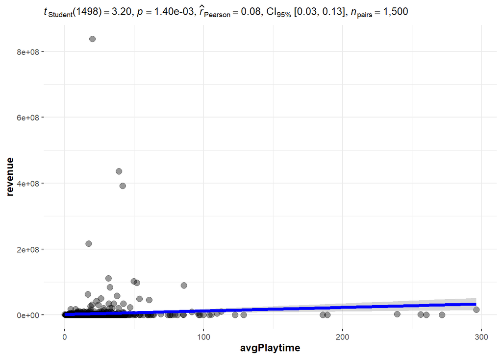

```r
library(ggstatsplot)

ggscatterstats(
  data = data,
  x = avgPlaytime ,
  y = revenue,
  bf.message = FALSE,
  marginal = FALSE # remove histograms
)
```

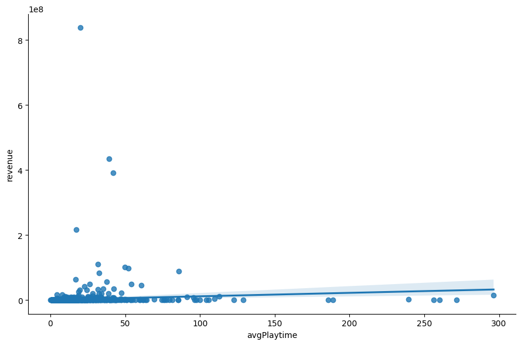

[figure not shown]

```python
sns.lmplot(x='avgPlaytime', y='revenue', data=data, height=6, aspect=1.5)
```

Ten opět potvrzuje slabou, ale významnou pozitivní korelaci.